# Analise da atividade dos parlamentares no Twitter no ano de 2019

Alice Fernandes Silva, Elton Dantas de Oliveira Mesquita, Igor Matheus Castor Diniz Pinheiro

```r
atividade = read_projectdata %>%
glimpse(atividade)
```

```
Error in FUN(left, right) : argumento não-numérico para operador binário
```

Desde o uso das novas tecnologias nas eleições americanas de 2008, o Twitter tem se tornado uma plataforma para as atividades políticas, criando um canal para a interação entre políticos e eleitores. A comunicação política com o uso de mídia social é parte das atividades congressistas nos dias atuais. Além disto, o Twitter se constitui como importante meio para o ganho de popularidade com fins eleitorais. O cenário político brasileiro não é diferente e a cada dia nossos parlamentares estão mais ativos nas redes sociais. Com base nisto, este relatório se propõe a respoder algumas questões de curiosidade à população.

OBS.: Deputados sem perfis ou com número de seguidores não registrados foram desconsiderados.

# Como é a relação entre o engajamento total de cada parlamentar e o seu número de seguidores?

```r
atividade_dep = atividade %>%
                  na.omit(seguidores) %>%
                  filter(casa == "câmara")
```

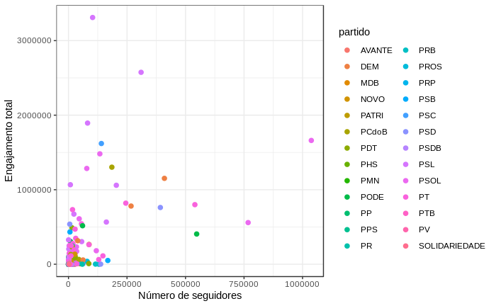

```r
  atividade_dep %>%
    ggplot(aes(x = seguidores,
               y = engaj_total,
               color = partido)) +
    geom_point(stat = "identity",
               size = 2) +
    xlab("Número de seguidores") +
    ylab("Engajamento total")
```

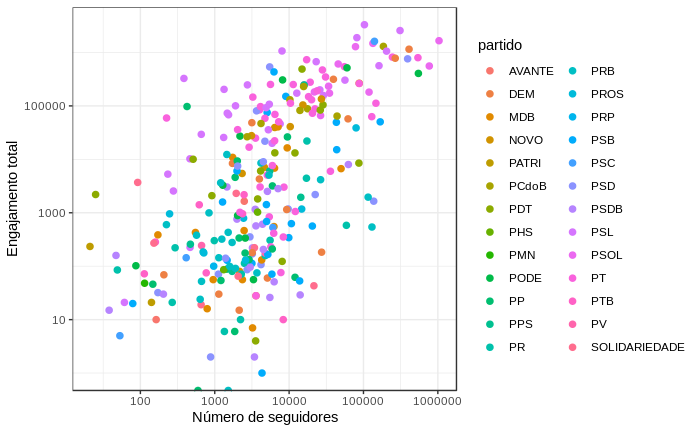

```r
 atividade_dep %>%
    ggplot(aes(x = seguidores,
               y = engaj_total,
               color = partido)) +
    geom_point(stat = "identity",
               size = 2) +
    scale_x_log10() +
    scale_y_log10() +
    xlab("Número de seguidores") +
    ylab("Engajamento total")
```

Com a escala linear, não fica claro um padrão que indique alguma relação. Há sim uma concentração considerável de deputados que possuem pouco engajamento e poucos seguidores, entretanto o aumento de engajamento não significa necessariamente o aumento de seguidores e vice-versa. Já com a escala logarítmica, que considera a distância proporcional entre os pontos, conseguimos uma melhor visão da distribuição dos pontos antes concentrados nos valores mais baixos. Agora verificamos um certo padrão que nos indica uma relação positiva entre o engajamento total e o número de seguidores dos parlamentares.

# Levando em consideração os parlamentares e seus respectivos alcances em redes sociais, quais são os partidos que possuem o maior poder de influência no twitter?

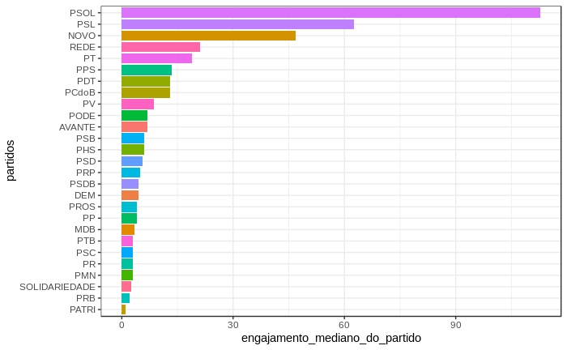

```r
engaj_mediano_partido =
  atividade %>%
  na.omit(engaj_mediano) %>%
  group_by(partido) %>%
  filter(partido != 'S/Partido') %>%
  summarise(engaj_med_part = median(engaj_mediano))
engaj_mediano_partido %>%
  group_by(partido)%>%
  ggplot(aes(x= reorder(partido, engaj_med_part), y= engaj_med_part,fill = partido) ) +
  geom_col(show.legend = FALSE)+
  labs(y='engajamento_mediano_do_partido', x= 'partidos')+
  coord_flip()
```

Considerando que o partido que possui maior poder de influência nas redes sociais é aquele que possui maior nível de engajamento, e evitando os pontos fora da curva, o que responde nossa pergunta é a mediana dos dos engajamentos_medianos de cada partido. Dessa forma poodemos perceber no gráfico que o PSOL e PSL estão bem a frente. O que difere do pensamento crítico do autor da questão, o qual imaginava PSOL, PT e PSDB. Importante ressaltar que o engajamento_mediano de cada partido é a mediana do engajamento de todos os seus parlamentares, que por sua vez são likes e retweets em seu conteúdo, ou seja aquele partido que possui maior engajamento mediano, é o partido que possui um número considerável de ações (likes/retweets emseu material).

# O quão ativos no twitter são os deputados do PSL (governo) e do PSOL (oposição)?

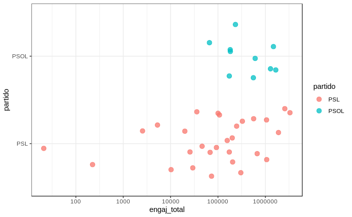

```r
atividade_dep %>%
  filter(partido == "PSL" | partido == "PSOL") %>%
  ggplot(aes(x = engaj_total,
             y = partido,
             color = partido))+
  geom_jitter(alpha = 0.75,
              size = 3) +
  scale_x_log10()
```

Para a análise, entendeu-se como atividade o engajamento total de cada parlamentar. Considerando a diferença entre o número de deputados dos dois partidos e a variação proporcional entre os pontos registrados, percebemos que os dois partidos possuem uma concentração maior de pontos à direita. Isto pode nos indicar uma certa semelhança de atuação para ambos. Entretanto, enquanto o PSOL possui apenas um deputado com engajamento abaixo de 100.000, o PSL possui um número expressivo de deputados abaixo deste valor. Portanto, o PSOL é mais ativo no twitter que o PSL.

# Os parlamentares do PSL e PSOL possuem maior nível de influência em tweets de próprio conteúdo ou em retweets?

```r
camara_psl_psol = atividade %>%
    filter(casa == "câmara") %>%
  filter(partido == "PSL" | partido == "PSOL") %>%
  filter(twitter != "NA")
glimpse(camara_psl_psol)
```

```
Observations: 55
Variables: 19
$ id_parlamentar        <chr> "204521", "204545", "204544", "204509", "204374", "204388", "204520", "2…
$ casa                  <chr> "câmara", "câmara", "câmara", "câmara", "câmara", "câmara", "câmara", "c…
$ nome_eleitoral        <chr> "ABOU ANNI", "ALÊ SILVA", "ALEXANDRE FROTA", "ÁUREA CAROLINA", "BIA KICI…
$ partido               <chr> "PSL", "PSL", "PSL", "PSOL", "PSL", "PSL", "PSL", "PSL", "PSL", "PSL", "…
$ UF                    <chr> "SP", "MG", "SP", "MG", "DF", "RS", "MG", "SP", "RJ", "SC", "MG", "RJ", …
$ twitter               <chr> "abouannipv", "oficialalesilva", "alefrotabrasil", "aureacarolinax", "Bi…
$ seguidores            <dbl> NA, 464, 161745, 33960, 81544, NA, 7575, 103029, 23127, 5906, 278, NA, 1…
$ segue                 <dbl> NA, 267, 2015, 2459, 742, NA, 63, 156, 907, 91, 429, NA, 463, 303, 660, …
$ n_proprio             <dbl> 0, 39, 830, 440, 368, 0, 38, 776, 533, 13, 44, 0, 228, 326, 134, 0, 94, …
$ n_retweet             <dbl> 0, 4, 169, 132, 625, 0, 3, 223, 134, 4, 3, 0, 27, 79, 89, 0, 3, 0, 0, 12…
$ engaj_total           <dbl> 0, 10231, 566011, 233521, 1893839, 0, 46227, 3310137, 672801, 19964, 255…
$ engaj_total_proprio   <dbl> 0, 186, 320063, 145508, 717602, 0, 21803, 2822907, 429406, 1720, 104, 0,…
$ engaj_total_retweet   <dbl> 0, 10045, 245948, 88013, 1176237, 0, 24424, 487230, 243395, 18244, 2451,…
$ engaj_mediano         <dbl> 0.0, 4.0, 134.0, 68.5, 773.0, 0.0, 243.0, 848.0, 309.0, 127.0, 2.0, 0.0,…
$ engaj_mediano_proprio <dbl> 0.0, 4.0, 60.0, 33.5, 0.0, 0.0, 182.0, 88.0, 65.0, 103.0, 2.0, 0.0, 10.0…
$ engaj_mediano_retweet <dbl> 0, 0, 0, 0, 202, 0, 0, 0, 0, 0, 0, 0, 0, 0, 0, 0, 0, 0, 0, 0, 0, 0, 0, 0…
$ engaj_max             <dbl> 0, 8171, 20348, 49238, 52614, 0, 19559, 33584, 19730, 10218, 1662, 0, 17…
$ engaj_max_proprio     <dbl> 0, 14, 7271, 49238, 27501, 0, 9516, 33584, 13034, 340, 9, 0, 3566, 12444…
$ engaj_max_retweet     <dbl> 0, 8171, 20348, 13382, 52614, 0, 19559, 28088, 19730, 10218, 1662, 0, 17…
```

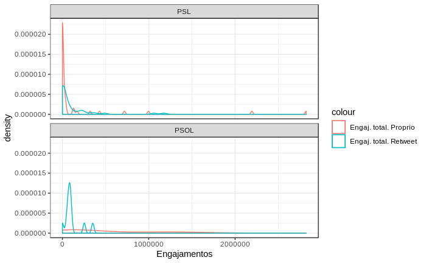

```r
camara_psl_psol %>%
  ggplot()+
  geom_density(aes(x=camara_psl_psol$engaj_total_proprio, color='Engaj. total. Proprio'))+
  geom_density(aes(x=camara_psl_psol$engaj_total_retweet, color='Engaj. total. Retweet'))+
  labs(x='Engajamentos')+
  scale_x_continuous()+
  facet_wrap(~partido, ncol=1)
```

A partir do gráfico é possível perceber que poucos parlamentares dos partidos PSL e PSOL tem um engajamento total em tweets próprio ou retweet que ultrapassa 1000000, entretanto o PSOL possui uma concetração maior de engajamento em retweets. Já o PSL possui alguns pontos isolados de engajamento total em conteúdo próprio, e o PSOL tem uma certa constância em conteúdo prórprio. É possível perceber que o PSL não possui um engajamento total própio favorável, sendo um pouco mais expressivo em conteúdo de retweets.